# Chapter 3 - Logistic Regression

## Overview of the data

The purpose of the analysis is to study the relationships between high/low alcohol consumption and some of the other variables in the data. Let us look closer to the cleaned data - collected in 2014 in Portuguese secondary schools from a survey about alcohol consumption and students’ achievements in mathematics (math) and Portuguese language (por) - resulting from the [Data Wrangling](https://github.com/tajataja/IODS-project/blob/master/data/create_alc.R).

The same answerers of two different classes have been combined. In addition;

- The variables not used for joining the two data have been combined by averaging (including the grade variables)
- ‘alc_use’ is the average of alcohol usage during weekdays ‘Dalc’ and and weekends ‘Walc’
- ‘high_use’ is TRUE if ‘alc_use’ is higher than 2 and FALSE otherwise

```r
date()
```

```
## [1] "Thu Nov 18 09:06:29 2021"
```

```r
#Reading the data
pormath = read.table(file="pormath.txt", sep=",", header=TRUE)

#Structure and dimensions of the data
str(pormath)
```

```
## 'data.frame':    370 obs. of  51 variables:
##  $ school    : chr  "GP" "GP" "GP" "GP" ...
##  $ sex       : chr  "F" "F" "F" "F" ...
##  $ age       : int  15 15 15 15 15 15 15 15 15 15 ...
##  $ address   : chr  "R" "R" "R" "R" ...
##  $ famsize   : chr  "GT3" "GT3" "GT3" "GT3" ...
##  $ Pstatus   : chr  "T" "T" "T" "T" ...
##  $ Medu      : int  1 1 2 2 3 3 3 2 3 3 ...
##  $ Fedu      : int  1 1 2 4 3 4 4 2 1 3 ...
##  $ Mjob      : chr  "at_home" "other" "at_home" "services" ...
##  $ Fjob      : chr  "other" "other" "other" "health" ...
##  $ reason    : chr  "home" "reputation" "reputation" "course" ...
##  $ guardian  : chr  "mother" "mother" "mother" "mother" ...
##  $ traveltime: int  2 1 1 1 2 1 2 2 2 1 ...
##  $ studytime : int  4 2 1 3 3 3 3 2 4 4 ...
```

[output cut: 37 more lines]

```r
#Names of the columns
colnames(pormath)
```

```
##  [1] "school"     "sex"        "age"        "address"    "famsize"
##  [6] "Pstatus"    "Medu"       "Fedu"       "Mjob"       "Fjob"
## [11] "reason"     "guardian"   "traveltime" "studytime"  "schoolsup"
## [16] "famsup"     "activities" "nursery"    "higher"     "internet"
## [21] "romantic"   "famrel"     "freetime"   "goout"      "Dalc"
## [26] "Walc"       "health"     "n"          "id.p"       "id.m"
## [31] "failures"   "paid"       "absences"   "G1"         "G2"
## [36] "G3"         "failures.p" "paid.p"     "absences.p" "G1.p"
## [41] "G2.p"       "G3.p"       "failures.m" "paid.m"     "absences.m"
## [46] "G1.m"       "G2.m"       "G3.m"       "alc_use"    "high_use"
## [51] "cid"
```

The structure of the data looks good. There are 370 observations of 51 variables *(see colnames above)*, such as gender, age, information about family’s education, study time, alcohol consumption etc. The entire attribute information you can find from [here](https://archive.ics.uci.edu/ml/datasets/Student+Performance).

## Chosen variables and hypothesis

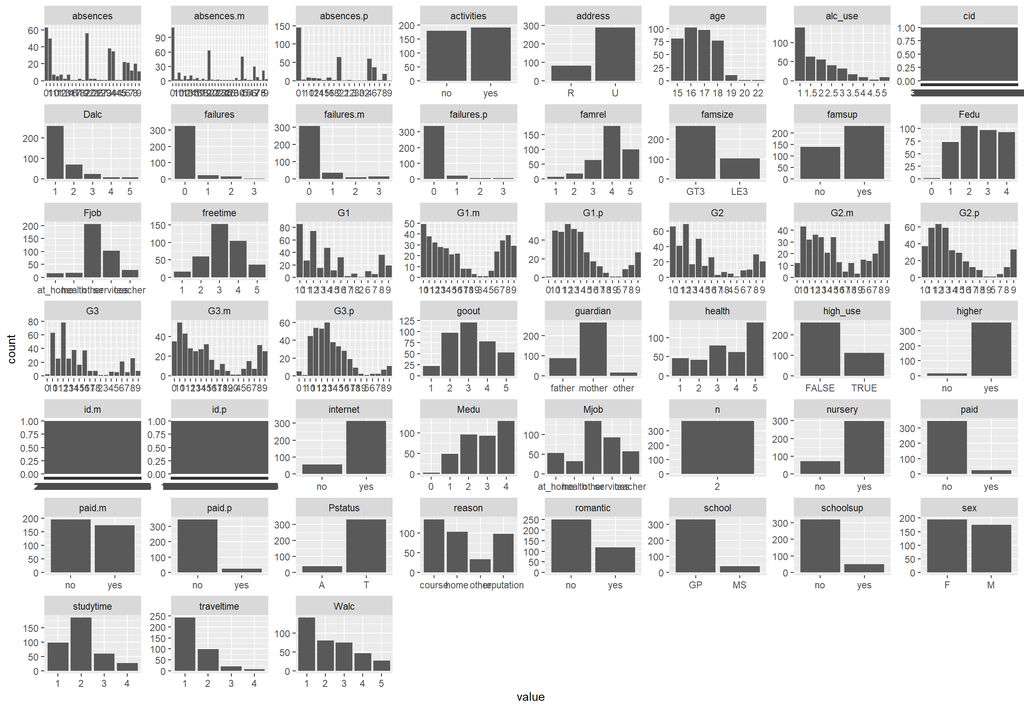

```r
library(tidyr); library(dplyr); library(ggplot2)
#Drawing a bar plot of each variable
gather(pormath) %>% ggplot(aes(value)) + facet_wrap("key", scales = "free") + geom_bar()
```

To examine the relationships related to the alcohol consumption, some variables need to be chosen. In this report we have chosen *age, absences, going out with friends (goout)* and *final grade (G3)* to be compared with *alcohol consumption (alc_use)* and whether it is *highly used or not (high_use)*.

> My personal hypotheses
- Student’s age in relation to alcohol consumption
  - The hypothesis is, that there is positive correlation between these two variables, ergo alcohol consumption is increasing with age. This is mainly due to the law that sets an age limit for alcohol consumption.
- Student’s frequency to go out with friends in relation to alcohol consumption
  - The hypothesis is, that there is positive correlation between these two variables, ergo alcohol consumption is the higher the more the student goes out with friends. This is based on the possibility to use alcohol in parties and hang-outs with groups of friends. Alcohol may be more likely to be used with friends than alone.
- Student’s absences (from lessons) in relation to alcohol consumption
  - The hypothesis is, that there is positive correlation between these two variables, ergo alcohol consumption is the higher the more the student have absences. This is just a hypothesis, the absence does not mean that the student would be out drinking. However, there is stronger possibility for it when it is known that the student is not in school.
- Student’s final grade in relation to alcohol consumption
  - The hypothesis is, that there is negative correlation between these two variables, ergo the higher grades the student have the less the student uses alcohol. The alcohol usage does not necessary affect the ability to success in school subjects. However, again, the alcohol is unlikely to be used while studying. So the high alcohol consumption may replace the time and capacity of studying.

## Numerical and graphical interpretation

Let us begin with a **numerical overview** of all four chosen variables and high/low alcohol consumption; *(high_use) ~ age, goout, absences* and *final grade (G3)*:

```r
#Producing summary statistics by group from the chosen variables

#Gender, high/low alcohol consumption, number of observations, mean age
pormath %>% group_by(sex, high_use) %>% summarise(count = n(), mean_age = mean(age))
```

```
## # A tibble: 4 x 4
## # Groups:   sex [2]
##   sex   high_use count mean_age
##   <chr> <lgl>    <int>    <dbl>
## 1 F     FALSE      154     16.6
## 2 F     TRUE        41     16.5
## 3 M     FALSE      105     16.3
## 4 M     TRUE        70     16.9
```

The **mean age** is approximately equal for all females and for males that do not use much alcohol. Only the age of males having a high alcohol consumption is slightly higher. The number of females using a lot of alcohol (41, *see females high_use FALSE > 154*) is the smallest out of these four categories (females and males with high/low alcohol consumption). Also the male students using alcohol more than 2 times a week (high_use) are in minority (70, *see males high_use FALSE > 105*).

```r
#Gender, high/low alcohol consumption, number of observations, mean of going out
pormath %>% group_by(sex, high_use) %>% summarise(count = n(), mean_go_out = mean(goout))
```

```
## # A tibble: 4 x 4
## # Groups:   sex [2]
##   sex   high_use count mean_go_out
##   <chr> <lgl>    <int>       <dbl>
## 1 F     FALSE      154        2.95
## 2 F     TRUE        41        3.39
## 3 M     FALSE      105        2.70
## 4 M     TRUE        70        3.93
```

The **mean of going out with friends** seem to be higher for those who have high alcohol consumption, in spite of the gender. In addition, females that have low alcohol consumption go out more often than males with low alcohol consumption.

```r
#Gender, high/low alcohol consumption, number of observations, mean of absences
pormath %>% group_by(sex, high_use) %>% summarise(count = n(), mean_absences = mean(absences))
```

```
## # A tibble: 4 x 4
## # Groups:   sex [2]
##   sex   high_use count mean_absences
##   <chr> <lgl>    <int>         <dbl>
## 1 F     FALSE      154          4.25
## 2 F     TRUE        41          6.85
## 3 M     FALSE      105          2.91
## 4 M     TRUE        70          6.1
```

The **absences** have clear differences related to high/low alcohol consumption. For both, females and males, having a high alcohol consumption the mean of absences is over 6 times when compared to the low alcohol consumers *(see females 4.25 and males 2.91)*. Females that have high alcohol consumption have more absences than males with high alcohol consumption.

```r
#Gender, high/low alcohol consumption, number of observations, mean grade
pormath %>% group_by(sex, high_use) %>% summarise(count = n(), mean_grade = mean(G3))
```

```
## # A tibble: 4 x 4
## # Groups:   sex [2]
##   sex   high_use count mean_grade
##   <chr> <lgl>    <int>      <dbl>
## 1 F     FALSE      154       11.4
## 2 F     TRUE        41       11.8
## 3 M     FALSE      105       12.3
## 4 M     TRUE        70       10.3
```

The **final grades** seem very similar for all females, despite their alcohol use. There is even slight increase in grades among females using alcohol more frequently (11.8 *vs. 11.4*). For males a clear difference can be observed. Males not using much alcohol have a lot higher grades (12.3) than the ones using alcohol more often (10.3).

### Bar plots

Let us continue by drawing a bar plots out of all four chosen variables and alcohol consumption; **A** *age*, **B** *goout*, **C** *absences*, **D** *final grade (G3)*, **E** *alc_use* and **F** *high_use*:

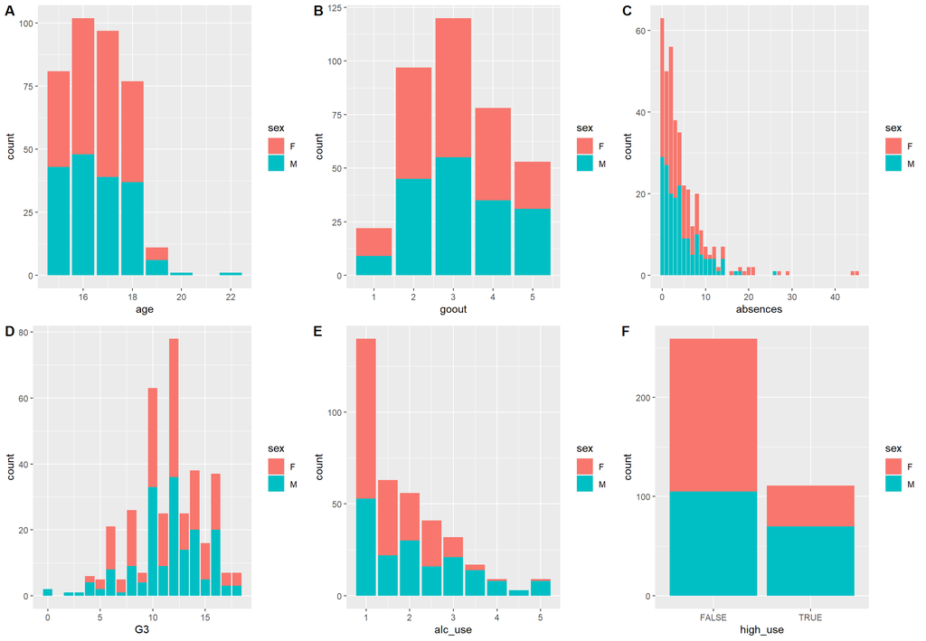

```r
library(tidyr); library(dplyr); library(ggplot2); library(cowplot)

#Drawing a bar plot of each variable (alc_use, high_use and 4 chosen variables)


#Initializing a barplot of age
g1 <- ggplot(pormath, aes(x = age, fill = sex)) + geom_bar() #+ ylab("age")

#... of going out with friends (goout)
g2 <- ggplot(pormath, aes(x = goout, fill = sex)) + geom_bar()

#... of absences
g3 <- ggplot(pormath, aes(x = absences, fill = sex)) + geom_bar()

#... of final grade (G3)
g4 <- ggplot(pormath, aes(x = G3, fill = sex)) + geom_bar()

#... of alcohol consumption (alc_use)
g5 <- ggplot(pormath, aes(x = alc_use, fill = sex)) + geom_bar()

#... of whether the consumption is high/low (high_use)
g6 <- ggplot(pormath, aes(x = high_use, fill = sex)) + geom_bar()


#Plotting all 4 barplots
plot_grid(g1, g2, g3, g4, g5, g6, labels="AUTO")
```

All the bar plots look reasonable. There seems to be more female answerers, which ages are varying mainly between 15-18 years. Males seem to go out with friends just slightly more often than females (goout - bar 5) and there are more males with high alcohol consumption.

Let us now examine the relationships and correlation between chosen 4 variables and alcohol consumption:

```r
library(GGally)
```

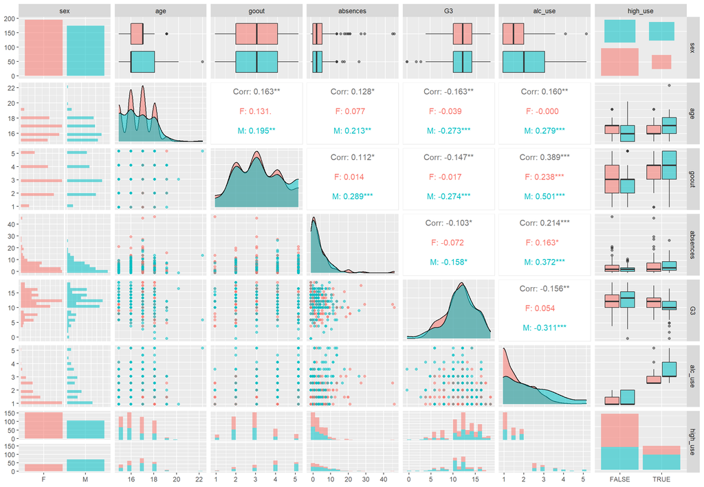

```r
library(ggplot2)
library(dplyr)

#Choosing a handful of columns to keep
keep_columns <- c("sex", "age", "goout", "absences", "G3", "alc_use", "high_use")

#Selecting the 'keep_columns' to create a new dataset
data <- select(pormath, one_of(keep_columns))

#Creating a plot matrix with ggpairs(), colouring has been set by gender (M=blue, F=red)
p <- ggpairs(data, mapping = aes(col=sex, alpha=0.3), lower = list(combo = wrap("facethist", bins = 20)))

#Drawing the plot
p
```

There are few more female answerers than men. The distribution shown along the diagonal of the plot series are fairly similar between female and male, excluding age and alcohol consumption. The age distribution has higher peaks for females and high alcohol usage is slightly more common among males.

**According to the correlations the hypotheses are mainly good**. I did not make differences between female and male students so that brought couple of surprises. The lack of correlation of age and final grades with alcohol usage for females was not expected. When the genders are combined the observations follow the above-mentioned hypotheses.

### Box plots

Let us still look at the box plots. We will be comparing the chosen variables with whether the student has a high alcohol consumption or not; **A** *age*, **B** *goout*, **C** *absences*, **D** *final grade (G3)*.

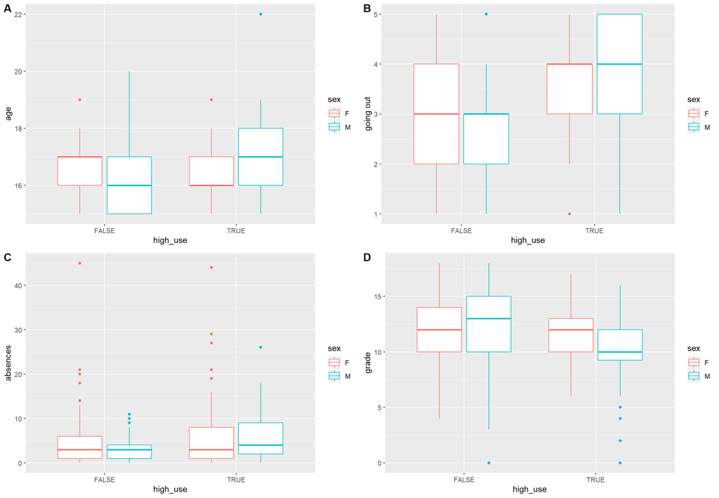

```r
library(cowplot)

#Let us do boxplots out of 4 variable sets

#Initializing a boxplot of high_use and age
g11 <- ggplot(pormath, aes(x = high_use, y = age, col = sex)) + geom_boxplot() + ylab("age")

#... of high_use and going out with friends (goout)
g22 <- ggplot(pormath, aes(x = high_use, y = goout, col = sex)) + geom_boxplot() + ylab("going out")

#... of high_use and absences
g33 <- ggplot(pormath, aes(x = high_use, y = absences, col = sex)) + geom_boxplot() + ylab("absences")

#... of high_use and final grade (G3)
g44 <- ggplot(pormath, aes(x = high_use, y = G3, col = sex)) + geom_boxplot() + ylab("grade")

#Plotting all 4 boxplots
plot_grid(g11, g22, g33, g44, labels = "AUTO")
```

In box plots the thicker line in the middle of the box shows the median of the answers. The edges of the box show the lower and upper quartile of the observations. The vertical lines outside the box are called ‘whiskers’ and the dots represent the maximum and minimum answers.

High consumption of alcohol is slightly more common among males with higher age (~17 years). Otherwise the age **does not** have clear influence according to the box plot. Instead, the **correlation between going out with friends and high alcohol usage** is clearly visible. The median of goout for females and males is approximately 4 times a week where the students with low alcohol consumption have a median of goout = 3.

Also **absences** are more common when there is high alcohol usage (positive correlation). The differences may seem small in the box plot, but this is only because the maximum values of absences are far from the median (exceeding even 40 absences). However, the above examined numerical tables and correlations reveal the truth among students that are not missing the classes over 20 times. When looking at the final grades the **negative correlation is visible with males**, ergo for males the grades are higher when the alcohol consumption is low. For females there are no clear differences perceptible.

## Logistic regression model

Let us do a logistic regression model to statistically explore the relationship between the above chosen four variables and the binary high/low usage of alcohol *(target variable)*.

```r
#Finding the model with glm()
m <- glm(high_use ~ age + goout + absences + G3, data = pormath, family = "binomial")

#Printing out a summary of the model
summary(m)
```

```
##
## Call:
## glm(formula = high_use ~ age + goout + absences + G3, family = "binomial",
##     data = pormath)
##
## Deviance Residuals:
##     Min       1Q   Median       3Q      Max
## -1.8967  -0.7525  -0.5409   0.9467   2.2946
##
## Coefficients:
##             Estimate Std. Error z value Pr(>|z|)
## (Intercept) -3.77834    1.96186  -1.926  0.05412 .
## age          0.04563    0.11022   0.414  0.67890
## goout        0.70668    0.11917   5.930 3.03e-09 ***
## absences     0.07315    0.02237   3.270  0.00108 **
## G3          -0.04472    0.03923  -1.140  0.25435
## ---
## Signif. codes:  0 '***' 0.001 '**' 0.01 '*' 0.05 '.' 0.1 ' ' 1
##
## (Dispersion parameter for binomial family taken to be 1)
##
##     Null deviance: 452.04  on 369  degrees of freedom
## Residual deviance: 388.67  on 365  degrees of freedom
## AIC: 398.67
##
## Number of Fisher Scoring iterations: 4
```

```r
#Printing out the coefficients of the model
coef(m)
```

```
## (Intercept)         age       goout    absences          G3
## -3.77834234  0.04562870  0.70667982  0.07314823 -0.04471930
```

### Odds ratios and confidence interval

Next we will look closer to coefficients of the model as **odds ratios**. We will also provide a **confidence interval** for them.

```r
#Computing odds ratios (OR)
OR <- coef(m) %>% exp

#Computing confidence intervals (CI)
CI <- confint(m) %>% exp
#Printing out the odds ratios with their confidence intervals
cbind(OR, CI)
```

```
##                     OR        2.5 %   97.5 %
## (Intercept) 0.02286056 0.0004637374 1.033922
## age         1.04668570 0.8430071337 1.299954
## goout       2.02724925 1.6139414455 2.577757
## absences    1.07589001 1.0312932049 1.127070
## G3          0.95626587 0.8852281993 1.032878
```

The odds ratio is used to quantify the relationship between chosen variables and target variable. Odds **higher than 1** mean that the chosen variable is associated with TRUE of the target variable (student has high alcohol consumption). The odds ratio is highest for go_out. Odds ratio exceeds one also for age and absences. Final grade is the only which odds ratio is remaining under 1 *(~0.96)*.

Let us look closer to the confidence intervals. In case the confidence interval contains the value one we can conclude that there is **no evidence of an association** between chosen variable and target variable. In our case this applies for age *(0.8 - 1.3)* and final grade *(0.9 - 1.0)*. Thus, there is no association between high_use and age or final grade. Instead, both go_out and absences’ confidence intervals are above one, and thereby they do have some association with the high alcohol consumption.

These results would lead to a new conclusion. Even though there has been small correlation visible between age and final grades in terms of high_use, according to odds ratios and confidence intervals they should *not be included* into the model anymore. Their association is too small or casual. As predicted in the hypothesis **going out with friends and absences from lessons do associate with high alcohol consumption**. Thus, let us keep these two variables (goout, absences) and move on to explore the predictive power of our model.

## Predictive power of the model

Using the variables which, according to the logistic regression model above, had a statistical relationship with high/low alcohol consumption (goout, absences), we will now explore the predictive power of our model.

```r
#Fitting the model
m <- glm(high_use ~ goout + absences, data = pormath, family = "binomial")

#Predicting - predict() - the probability of high_use
probabilities <- predict(m, type = "response")

#Adding the predicted probabilities to 'alc'
alc <- mutate(pormath, probability = probabilities)

#Using the probabilities to make a prediction of high_use
alc <- mutate(alc, prediction = probability > 0.5)

#Let us see the last ten original classes, predicted probabilities, and class predictions
select(alc, goout, absences, sex, high_use, probability, prediction) %>% tail(10)
```

```
##     goout absences sex high_use probability prediction
## 361     3        7   M     TRUE  0.28963176      FALSE
## 362     3        3   M     TRUE  0.23104046      FALSE
## 363     1        2   M     TRUE  0.06029226      FALSE
## 364     4        4   M     TRUE  0.40315734      FALSE
## 365     2        3   M    FALSE  0.12606082      FALSE
## 366     3        4   M     TRUE  0.24487648      FALSE
## 367     2        0   M    FALSE  0.10291931      FALSE
## 368     4        4   M     TRUE  0.40315734      FALSE
## 369     4        8   M     TRUE  0.47825016      FALSE
## 370     2        0   M    FALSE  0.10291931      FALSE
```

Above we have now a table for comparing the real values and the values originating from the probabilities and predictions. In case probability (to use alcohol more than 2 times a week) is 50% (0.5) the prediction results TRUE. In the table above we have last 10 observations of our data and one could say that the predictions do not look too good. 7 out of the 10 observations are in reality categorized as high_use = TRUE, but the predictions are all FALSE.

Let us tabulate the target variable (high_use) versus the predictions to see how well the predictions actually work.

```r
#Let us tabulate the target variable versus the predictions
table(high_use = alc$high_use, prediction = alc$prediction)
```

```
##         prediction
## high_use FALSE TRUE
##    FALSE   236   23
##    TRUE     65   46
```

The cases where high_use and prediction both result to FALSE or TRUE are the cases, where observations have been **predicted successfully**. The contradictions, with TRUE and FALSE or FALSE and TRUE, are the ones that have been **predicted wrong** (up right value, low left value). As most of the students do not use a lot of alcohol it is reasonable, that FALSE FALSE value is clearly highest. To see better the share of the other cases let us take percentages in use.

```r
#Tabulating the target variable versus the predictions as percentages
table(high_use = alc$high_use, prediction = alc$prediction) %>% prop.table() %>% addmargins()
```

```
##         prediction
## high_use      FALSE       TRUE        Sum
##    FALSE 0.63783784 0.06216216 0.70000000
##    TRUE  0.17567568 0.12432432 0.30000000
##    Sum   0.81351351 0.18648649 1.00000000
```

The share of the inaccurately classified individuals (miss-predicted observations) - ergo *training error* - has been calculated using below defined loss_function. The function in practice sums the wrong predictions in the data. **The share of training error is ~0.24** *(~0.06 + ~0.18 = ~0.24)*.

```r
#Defining a loss function (mean prediction error)
#Class is here high_use
loss_func <- function(class, prob) {
  n_wrong <- abs(class - prob) > 0.5
  mean(n_wrong)
}

#Calling loss_func to compute the average number of wrong predictions in the data
loss_func(class = alc$high_use, prob = alc$probability)
```

```
## [1] 0.2378378
```

## 10-fold cross-validation

Let us perform a 10-fold cross-validation on our model.

```r
#Defining a loss function (average prediction error)
loss_func2 <- function(class, prob) {
  n_wrong <- abs(class - prob) > 0.5
  mean(n_wrong)
}

#K-fold cross-validation
library(boot)
cv <- cv.glm(data = alc, cost = loss_func, glmfit = m, K = 10)

#Average number of wrong predictions in the cross validation
cv$delta[1]
```

```
## [1] 0.2459459
```

> *Summary of my learning*

This week’s tasks were more challenging than lats week. Even now, everything is not clear but I think I managed well to complete all the necessary tasks + one bonus task. New plots were used and learned. Using the prediction model and all those odds ratios and 10-fold cross-validations were new and interesting ways to check if the variables do really associate and whether they could be predicted.

Regards, *Janina*